# Porocilo pri predmetu Analiza podatkov s programom R

Urška Rožman

# Izbira teme

Izbrala sem si temo z naslovom Analiza naravnega prirastka v Sloveniji in primerjava naravnega prirastka z drugimi Evropskimi državami. Analizirala bom rodnost, umrljivost in naravni prirastek v Sloveniji po regijah in spolu. V nadaljevanju pa ga bom primerjala s prirastkom v drugih Evropskih državah.

# Obdelava, uvoz in cišcenje podatkov

Podatke za prvo tabelo sem dobila na spletni strani statisticnega urada Slovenije ter jih uvozila v CSV obliki, podatke za drugo tabelo pa sem v HTML obliki uvozila iz spletne strani EUROSTAT.

Povezave na podatke: http://ec.europa.eu/eurostat/web/population-demography-migration-projections/births-fertitily-data/database http://pxweb.stat.si/pxweb/Dialog/varval.asp?ma=05I1002S&ti=&path=../Database/Dem_soc/05_prebivalstvo/25_selitveno_gibanje/05_05I10_naravno_gibanje/&lang=2

Prva tabela vsebuje stolpce: - ime kraja (imenska spremenljivka) - leto (številska spremenljivka) - število živorojenih moških (številska spremenljivka) - prikazuje rodnost moških po krajih in letih - število živorojenih ženske (številska spremenljivka) - prikazuje rodnost žensk po krajih in letih - število umrlih moških (številska spremenljivka) - prikazuje umrljivost moških po krajih in leti - število umrlih žensk (številska spremenljivka) - prikazuje umrljivost žensk po krajih in letih - naravni prirastek moških (številska spremenljivka) - prikazuje naravni prirastek moških po krajih in letih - naravni prirastek žensk (številska spremenljivka) - prikazuje naravni prirastek moških po krajih in letih - relativen naravni prirastek (številska spremenljivka) - število urmlih na 1000 prebivalcev (šteilska spremenljivka) - število živorojenih na 1000 prebivalcev (številska spremenljivka)

|  | kraj | leto | zivorojeni.moski | zivorojene.zenske | umrli.moski | umrle.zenske | naravni.prirast.moski | naravni.prirast.zenske | zivorojeni.na.1000 | umrli.na.1000 | naravni.prirast.na.1000.prebivalcev | skupni.prirast | velikost |
| --- | --- | --- | --- | --- | --- | --- | --- | --- | --- | --- | --- | --- | --- |
| 2 | Ajdovšcina | 2010 | 130 | 131 | 73 | 98 | 57 | 33 | 42 | 146 | 161 | 90 | pozitiven |
| 3 | Ajdovšcina | 2011 | 131 | 109 | 77 | 72 | 54 | 37 | 31 | 134 | 161 | 91 | pozitiven |
| 4 | Ajdovšcina | 2012 | 142 | 129 | 80 | 74 | 62 | 55 | 46 | 136 | 175 | 117 | pozitiven |
| 5 | Ajdovšcina | 2013 | 120 | 115 | 90 | 89 | 30 | 26 | 28 | 149 | 142 | 56 | pozitiven |
| 6 | Ajdovšcina | 2014 | 127 | 106 | 77 | 86 | 50 | 20 | 27 | 141 | 150 | 70 | pozitiven |
| 8 | Apace | 2010 | 15 | 15 | 15 | 16 | 0 | -1 | 109 | 141 | 4 | -1 | negativen |

Te stolpce sem precistila (mesta kjer ni bilo podatka sem zamenjala z NA), izbrisala nepotrebne stolpce in vrstice ter zagotovila, da bodo številske spremenljivke res številske. Tabelo sem locila na pet pod tabel, ki so bile locene glede na leto. Dodala sem stolpec “skupni.prirast” ki je seštevek naravnega prirasta moških in žensk. Da bi bilo filtriranje podatkov še lažje, sem dodala še stolpec “velikost” ki je urejenostna spremenljivka in sicer klasificira prirastek kot “pozitiven”,“negativen” oziroma “ni prirastka”.

Druga tabela, ki je bila uvožena v HTML obliki vsebuje podatke o naravnem prirastku evropskih držav. Najprej sem uvozila zgolj podatke o prirastku ki so klicani z eno spremenljivko,ter jih dala v matriko, kasneje pa še podatke o letih merjenja ter državah. Ko sem precistila nepotrebne podatke (zamenjava znakov “-”,“(”b“) z NA, ter pri vektorju držav in let napotrebne znake med željenimi državami) sem podatke, države in leta združila v eno tabelo. Ker želim analizirati le podatke od 2010-2013 sem ostale stolpce izbrisala.

|  | 2010 | 2011 | 2012 | 2013 |
| --- | --- | --- | --- | --- |
| Bulgaria | 1.57444 | 1.50856 | 1.50111 | 1.47992 |
| Czech Republic | 1.51363 | 1.42660 | 1.45163 | 1.45545 |
| Denmark | 1.87025 | 1.75169 | 1.72831 | 1.66802 |
| Germany (including former GDR) | 1.39206 | 1.36274 | 1.38138 | 1.39142 |
| Estonia | 1.72048 | 1.61316 | 1.55941 | 1.52109 |
| Ireland | 2.04899 | 2.02874 | 2.01304 | 1.95631 |

Nato sem narisala še nekaj grafov.

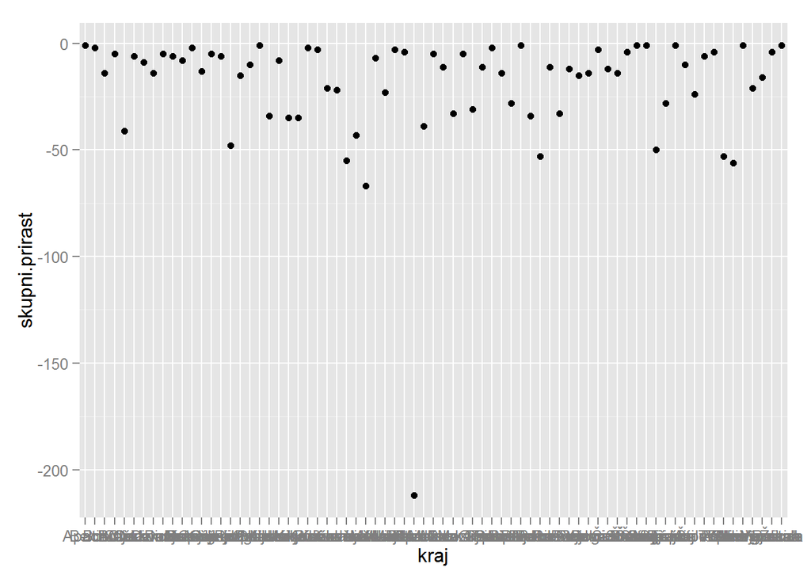

Prikazuje negativen prirast v letu 2010 po obcinah.

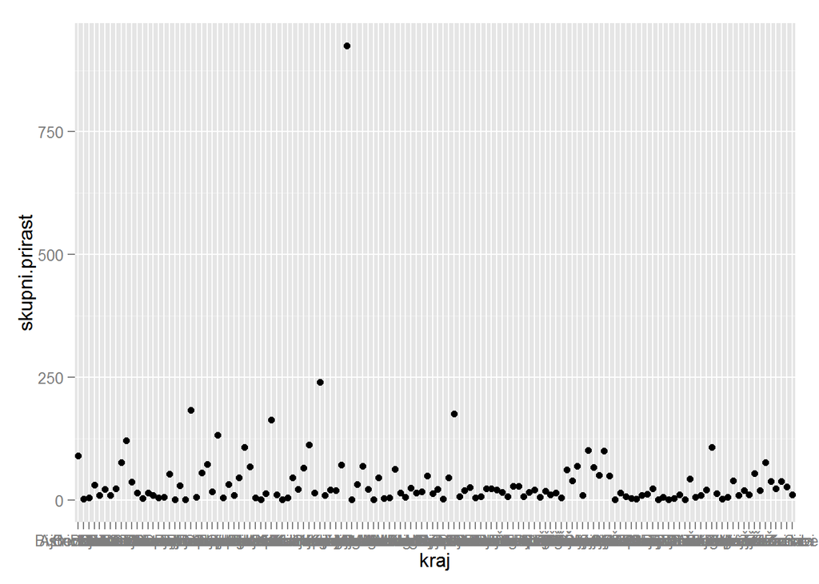

Prikazuje pozitiven prirast v letu 2010 po obcinah.

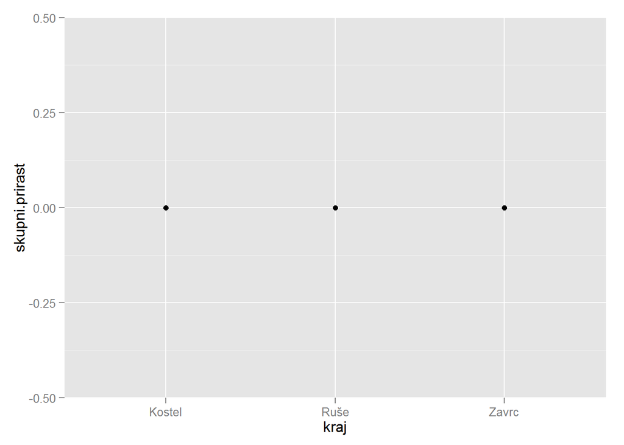

Prikazuje obcine v letu 2010, ki so brez prirastka.

# Analiza in vizualizacija podatkov

Preden sem zacela z izdelavo zemljevidov sem v tabele obcin dodala Ankaran, ki je novonastala obcina, zato je v tabelah s podatki še ni bilo. Nato sem se lotila izdelave.

### Zemljevid naravnega prirasta po po obcinah v Sloveniji v letu 2011

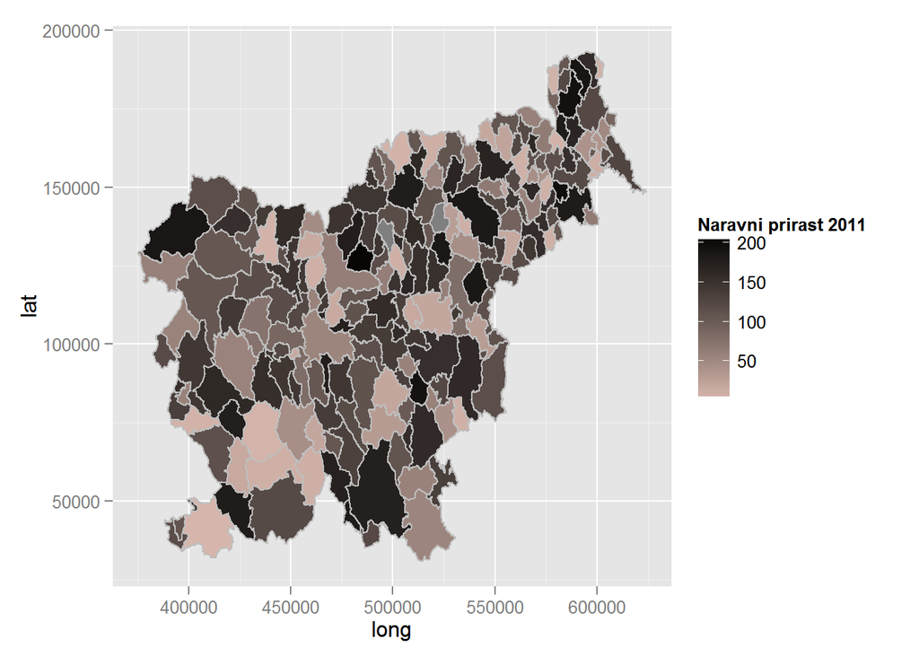

Zemljevid nam prikazuje naravni prirast v letu 2011 po obcinah. Najvecji absolutni naravni prirast je v Ljubljani, najmanjši pa v Mariboru. Njavecji relativni prirast je v Dol pri Ljublajni, najmanjši pa v Dravogradu.

### Zemljevid obcin spozitivnim prirastom, negativnim prirastom in obcin brez prirasta

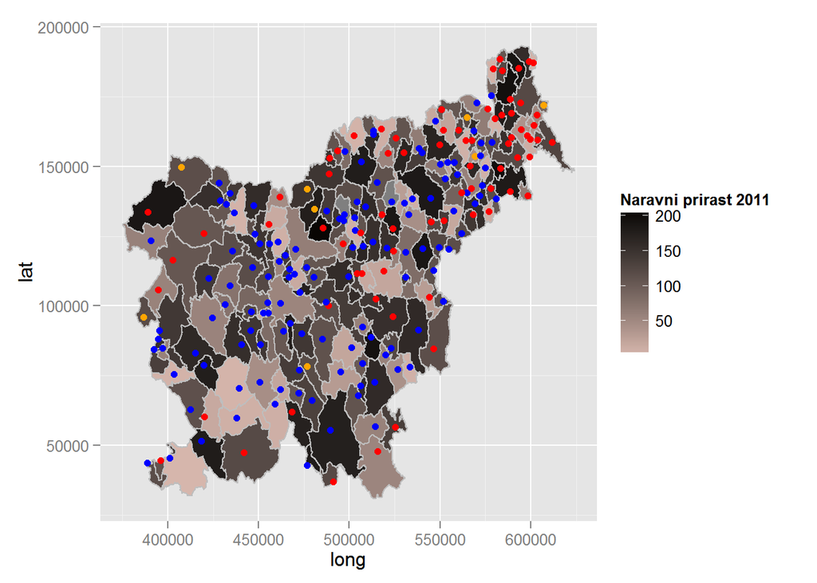

Zemljevid prikazuje skupni prirast v letu 2011, s pikami pa je oznacena velikost prirasta. Modra pika prikazuje vse obcine kjer je prirast pozitiven, rdeca tiste, kjer je negativen, rumena pa obcine brez prirasta.

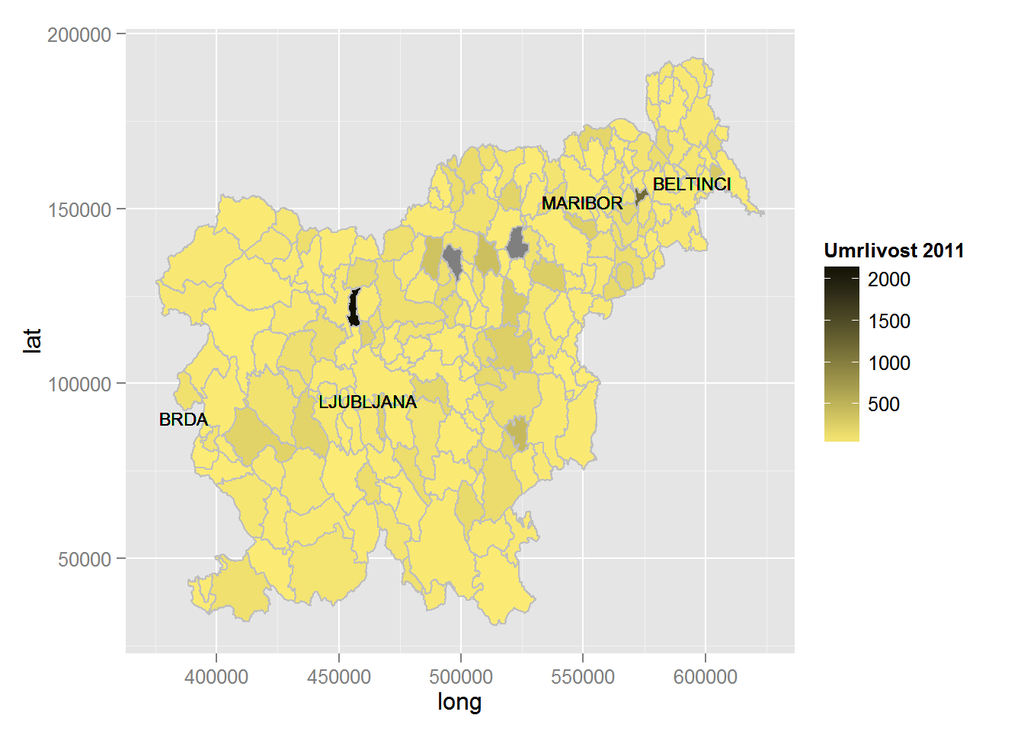

### Analiza naravnega prirasta po letih

Ugotovila sem, da je med leti 2010 in 2014 naravni prirast najvecji v Ljubljani in najmanjši v Mariboru.

### Analiza povprecnega naravnega prirasta po letih

Ugotovila sem, da je naravni prirast po letih od 2010 do 2013 padal,nato se 2014 spet narastel.

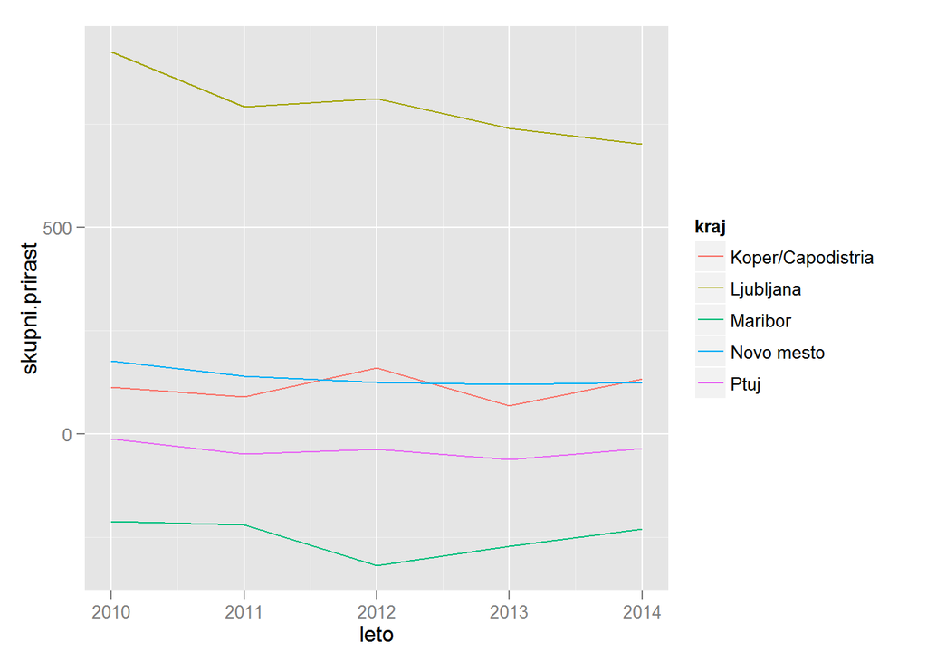

Graf prikazuje gibanje naravnega prirasta v nekaj izmed izbranih obcinah.

### Analiza živorojenih moških in žensk loceno po letih

Ugotovila sem, da povprecnono število živorojenih žensk po letih pada, prav tako tudi število živorojenih moških. Vsako leto pa je število živorojenih moških vecje od števila živorojenih žensk.

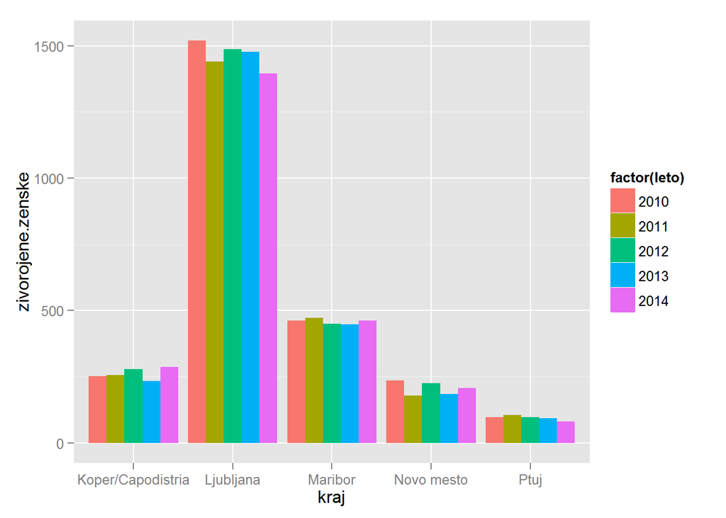

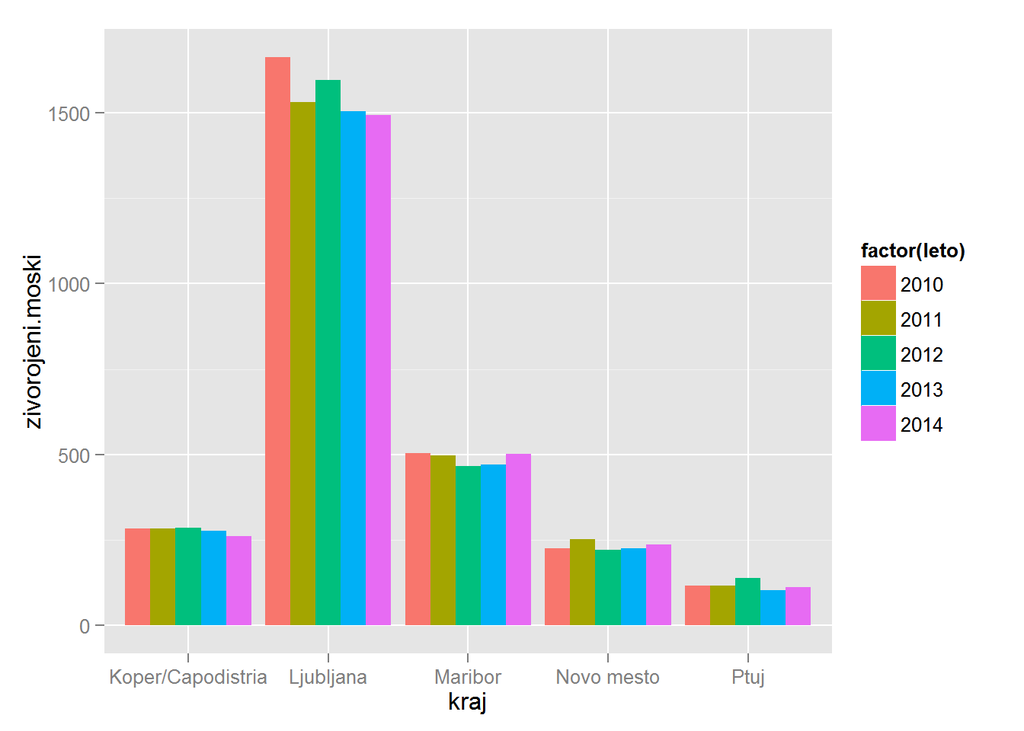

Prvi graf prikazuje gibanje števila živorojenih žensk v nekaj izmed izbranih obcin, drugi pa gibanje števila živorojenih moških.

### Analiza umrlih moških in žensk loceno po letih

| leto | zenske | moski |
| --- | --- | --- |
| 2010 | 45.06667 | 43.97619 |
| 2011 | 45.06667 | 43.97619 |
| 2012 | 46.65877 | 46.65877 |
| 2013 | 46.34597 | 45.28436 |
| 2014 | 46.34597 | 45.28436 |

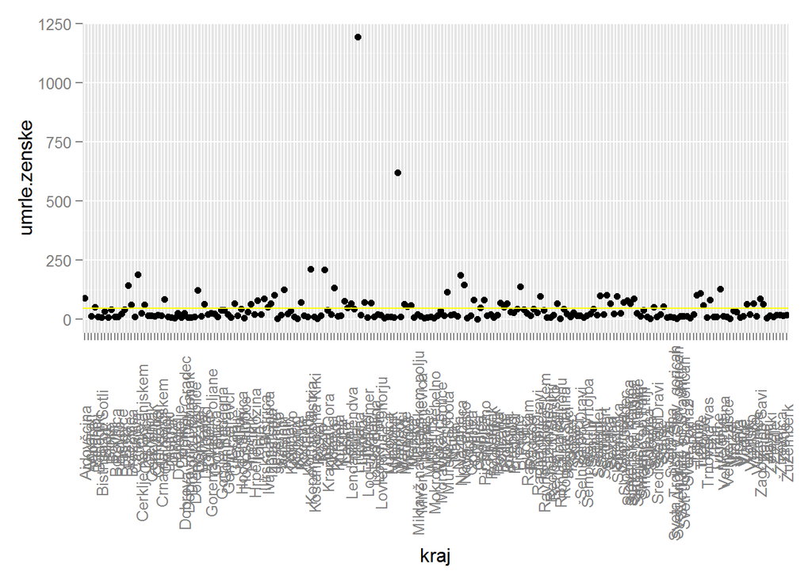

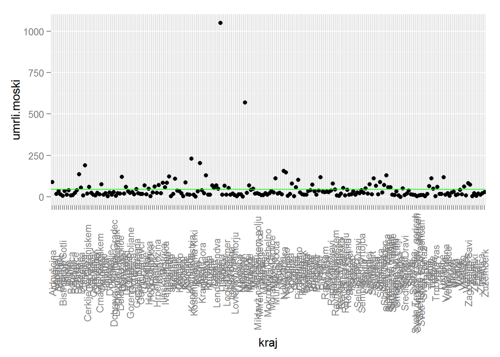

### Primerjava naravnega prirasta v Sloveniji z ostalimi Evropskimi državami

Ugotovila sem, da je imela najvecji povpprecni naravni prirast v letu 2010 Islandija,v letih 2011-2013 pa Turcija. Najmanjši navani prirast izmed Evropskih držav je imela v letih 2010 in 2011 Madžarska, v letu 2012 San marino, v letu 2013 pa Portugalska. Ugotovila sem, da je povprecni slovenski prirast vecji od povprecnega evropskega po letih.